# 03 — Reconstruct, build and audit a three-box model

**Learning goals:** reconstruct a scientific flux diagram; translate it through Excel records into native ESBMTK objects; explain contrasting organic/carbonate effects on pCO2; check the connections, whole-system budgets and a saved starting state.

**Provisional time: 55 minutes.** Diagram, paired flux equations and Excel reconciliation (15), four native mappings (20), boundary budget and checks (15), explanation (5).

**Reading key:** **Key term** = concept to notice. Blue **Question** panels identify student work; purple **Instructor answer** panels appear only in the instructor sheet. Code labels distinguish **Choose and explain**, **Understand and run**, and **Supplied implementation**. This practical is ungraded. Keep your explanations here; no separate submission is required. The coding cheatsheet is optional lookup support; essential syntax is explained locally.

## A1. What changes from 02?

This is a Boudreau-like benchmark with a different specification. Do not carry over 02's fitted k, ratio-derived geometry or total carbon inventory.

| Feature | 02 | 03/04 |
| --- | --- | --- |
| Geometry and conditions | Two layers, uniform T/S/P | Low-/high-latitude surface and deep boxes; box-specific conditions |
| Organic export | $kDIC_s(t)$ | Fixed POC export |
| Carbonate processes | Absent | PIC export, dissolution and net burial |
| Active atm–ocn boundary | Closed except the pulse | Weathering and net burial; forcing added in 04 |
| Reference state | Calibrated constraints | Saved values from a long benchmark run |

A **model state** is the set of current values that the model evolves: here, ocn DIC/TA, atm CO2 and the **snowline** (the deepest boundary of existing reactive carbonate sediment), along with auxiliary chemistry values. A **restart** uses saved values from an earlier run as the starting state of a new run. In C3 we will load a supplied state from a long benchmark run, then check that your reconstructed model changes little over 20 years. This avoids repeating the long calculation in class.

POC and PIC mean **particulate organic and inorganic carbon**. Here POC export includes full deep remineralization: conversion back to dissolved carbon. There is no explicit particle or nutrient inventory. The **rain ratio** is PIC/POC carbon export; the workbook prescribes this ratio and POC, then the loader derives PIC.

Read ESBMTK section 3 and Figure 3 (printed p. 1162; [online version](https://gmd.copernicus.org/articles/18/1155/2025/#section3)). Use these corrections:

- The organic-export label in the prose should be **F5**, not F3; F3 denotes circulation.
- The benchmark uses **F6/F5 = PIC/POC = 0.3**, not the inverted ratio in the prose.
- Weathering supplies **dissolved inorganic carbon** here, not organic carbon.

Figure 3 is an incomplete specification: its arrows omit equations, stoichiometry and an explicit dissolution return. Reconstruct those properties using the following assumptions and workbook inputs.

### Process rules for your equations

- Water carries both dissolved tracers at the **source concentration**. Draw the circulation loop L_b → H_b → D_b → L_b and both H_b ↔ D_b mixing directions.
- Each surface exchanges CO2 with the same finite atm. Use invasion and outgassing as in 01/02.
- Only L_b exports POC/PIC. The table supplies the benchmark's biological, carbonate and weathering assumptions beside their rows.
- Draw a distinct carbonate/sediment **process module** with an explicit dissolution return. Its snowline records sediment history; the module has no explicit sediment-carbon inventory. Detailed sediment equations remain optional.

```python
# Supplied implementation: run this support code as provided.
from pathlib import Path
import sys
import pandas as pd
import numpy as np

ROOT = next(p for p in (Path.cwd().resolve(), *Path.cwd().resolve().parents)
            if (p / 'teaching_config.py').is_file())
if str(ROOT) not in sys.path:
    sys.path.insert(0, str(ROOT))

from esbmtk import (
    Q_, ConnectionProperties, GasReservoir, Model, Species2Species,
    add_carbonate_system_1, add_carbonate_system_2,
    create_bulk_connections, initialize_reservoirs,
)
from model import postprocess_carbonate_horizons, run_model, standard_diagnostics
from presets import load_boudreau_parameters
from reservoir_inputs import reservoir_inventory_rows
from model_inputs import read_model_tables

WORKBOOK = ROOT / 'data' / 'Boudreau_2010' / 'model_definition.xlsx'
P = load_boudreau_parameters(WORKBOOK)
input_tables = read_model_tables(WORKBOOK)
STATE = ROOT / 'data' / 'Boudreau_2010' / 'steady_state'
from teaching_specification import BASELINE_PARAMETERS, workbook_connections
from teaching_audits import audit_benchmark_graph, audit_complete_model, audit_restart_drift
```

### A2. Inspect the numerical inputs

The workbook owns areas, volumes, box-specific T/S/P and initial states. The atmosphere has its own mole-fraction and total-air units. **The workbook concentrations initialize construction; C3 replaces them with the saved starting values.** Geometry, thermodynamic settings and process parameters stay the same.

For now inspect only reservoir and baseline parameter tables. Connection rows come after your reconstruction. Excel editing is not required.

```python
# Understand and run: read these supplied inputs before drawing.
display(pd.DataFrame(input_tables['OceanReservoirs']).set_index('Box ID'))
display(pd.DataFrame(input_tables['Atmosphere']).set_index('Box ID'))
baseline_parameters = pd.DataFrame(input_tables['ProcessParameters']).set_index('Parameter')
display(baseline_parameters.loc[list(BASELINE_PARAMETERS)])
```

## A3. Exercise 03.1: write the paired fluxes and label the diagram

### Step 1 — Write the paired fluxes

**Question — equations on arrows**

Complete both flux columns, including zero effects. Use one family expression for repeated water/gas arrows. Beside each row, note which changing model values affect its rate; write **fixed** for a prescribed constant rate. For net burial, identify the two fluxes being compared.

Use the notation and supplied hints below. Fill the table here or in the student Excel worksheet, whose amber fields are answer spaces. Write symbolic equations, not Excel calculation formulas.

#### Notation

Use **amount fluxes** $J_a^{DIC}(t)$ [mol C/yr] and $J_a^{TA}(t)$ [equivalents/yr] for process $a$. Positive follows the arrow: subtract at its source and add at its destination. The DIC superscript tracks carbon removed from/returned to dissolved inventories, even when carried as CO2 or particles. Gas exchange and net burial can be negative.

| Symbol | Meaning / units |
| --- | --- |
| $DIC_i(t),TA_i(t)$ | Evolving box concentrations [mol C/kg, eq/kg]; $i=L_b,H_b,D_b$ |
| $Q_{ij}$ | Water volume transport from $i$ to $j$ [m³/yr]; $\rho_iQ_{ij}$ converts it to mass transport [kg/yr] |
| $\rho_i,m_i$ | ESBMTK density $\rho(T_i,S_i,p_i)$ [kg/m³] and fixed box water mass $m_i=\rho_iV_i$ [kg] |
| $P_0,r,W_0$ | Prescribed POC carbon export [mol C/yr], PIC/POC rain ratio [dimensionless], weathering carbon input [mol C/yr] |
| $E(t),D(t),B_{net}(t)$ | Carbonate export, dissolution and signed net burial [mol C/yr] |

Here $p_i$ is water pressure; $pCO_{2,atm}$ is atmospheric CO2 partial pressure. **Transport convention:** use physical $\rho Q$ for these equations; B2 explains the historical unit conversion retained in the benchmark code.

#### Supplied hints and flux table

For gas exchange, chemistry supplies aqueous CO2:

$$c_i(t)=\mathcal C(DIC_i(t),TA_i(t);T_i,S_i,p_i).$$

Use area $A_i$ [m²] and velocity $v_i$ [m/yr]. Invasion uses $K_{0,i}pCO_{2,atm}(t)$; outgassing uses $c_i(t)$, both in mol/m³. Local solubility $K_{0,i}$ converts partial pressure to concentration. Form the two directional transfers before taking their difference. Supplied chemistry handles mol/kg and dry-air mole-fraction conversions.

For dissolution, **use this supplied dependency function**:

$$D(t)=\mathcal D\!\left(E(t),DIC_d(t),TA_d(t),z_{snow}(t);T_d,S_d,p_d,\alpha,z_0\right).$$

Here $d$ means D_b, $z_{snow}$ is the snowline, and $\alpha,z_0$ are workbook sediment parameters. The function lists the inputs used to calculate dissolution; its equations and code are supplied.

In this model, POC export changes DIC but leaves TA unchanged (the **DIC-only closure** in the table).

| Process | Arrow | $J^{DIC}(t)$ [mol C/yr] | $J^{TA}(t)$ [eq/yr] | Inputs / hint |
| --- | --- | --- | --- | --- |
| Q_* | Water: i -> j | Your expression | Your expression | Q_ij: water volume transport (m3/yr), from thc / mixing. Use source density and concentration. |
| G_L / G_H | Gas: atm -> surface i (signed) | Your expression | Your expression | piston_velocity, area; K0_i and c_i from local chemistry. Invasion minus outgassing. |
| POC | Organic export: your arrow | Your expression | Your expression | P_0 = poc_export; fixed, fully remineralized at depth; DIC-only closure. |
| PIC | Carbonate export: L_b -> module | Your expression | Your expression | r = rain_ratio (PIC/POC); CaCO3 formation removes 1 carbon and 2 TA equivalents. |
| W | Weathering: outside -> L_b | Your expression | Your expression | W_0 = weathering_dic; the model adds 2 TA equivalents per mole of DIC. |
| D | Dissolution: module -> D_b | $D(t)$ (supplied) | Your expression | D = sediment_response(E, DIC_d, TA_d, z_snow; T_d, S_d, p_d, alpha, z0). Reverse CaCO3 formation. |
| B_net | Net burial: module -> outside (signed) | Your expression | Your expression | Compare carbonate rain and dissolution, including old sediment; residual, not an extra drain. |

**Reference: biological TA effects and weathering**

The POC assumption omits nutrient/redox effects on TA. Nitrate uptake can increase TA and ammonium uptake can decrease it; a richer model needs the associated nutrient bookkeeping.

The model adds **1 mole of DIC and 2 equivalents of TA** through weathering. Real riverine input need not have exactly this 1:2 ratio.

### Step 2 — Label the diagram

**Question — label the diagram**

Draw and label the arrows with these expressions. Add states and the active atm–ocn boundary; distinguish chemistry diagnostics and sediment memory. Check water balance at H_b.

Label water arrows with $Q$: circulation $Q_{LH},Q_{HD},Q_{DL}$ and mixing $Q_{mix,down},Q_{mix,up}$. The paired $J$ equations describe the tracers they carry. F1–F8 remain paper aliases. Net burial is the signed amount left after dissolution, not an additional drain from deep water.

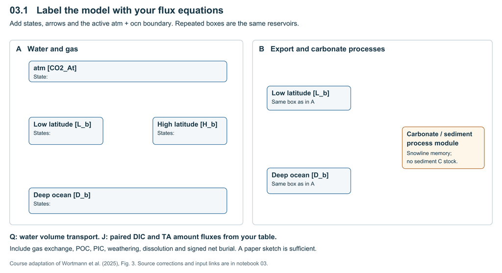

### Step 3 — Check one internal transfer

For any internal dissolved transfer of $X=DIC$ or $TA$, **flux and concentration tendency differ**:

$$\left.\frac{dX_i}{dt}\right|_{i\to j}=-\frac{J^X_{ij}(t)}{m_i},\qquad \left.\frac{dX_j}{dt}\right|_{i\to j}=+\frac{J^X_{ij}(t)}{m_j}.$$

**Question — check inventory cancellation**

For one internal arrow, use the supplied tendency rule above to show equal-and-opposite inventory changes. Do not rewrite the effects in prose.

> **Your explanation:** replace this placeholder with your answer.

### Interpret your fluxes on the DIC–TA plane

Reuse 01's top view: DIC is horizontal, TA vertical, and each contour has constant seawater pCO2 [µatm]. The supplied plot recalculates chemistry for the workbook's L_b inputs and benchmark T/S/p, rather than 01's uniform conditions. Its dot is an input reference, **not the saved starting state loaded in C3**. Treat each arrow as a local parcel change before transport and gas exchange.

```python
# Understand and run: use the contours to interpret your paired fluxes.
from teaching_plots import plot_carbonate_process_plane
plot_carbonate_process_plane(P);
```

**Question — interpret the paired fluxes**

From the dot, remove 20 µmol C/kg through POC export and separately through CaCO3 formation. Use your paired equations to draw the two DIC–TA vectors and predict the pCO2 changes from the contours. Why do the signs differ? Reverse the carbonate vector for dissolution. Reuse these vectors in 03.4; no additional flux-effects paragraph is needed.

> **Your explanation:** replace this placeholder with your answer.

### A4. Reconcile your drawing with Excel

Compare the water and gas connection rows below with your arrows. Identify water routes by **source + sink + flux_id**: all three circulation rows use `thc`, so that ID alone is not unique. Check boundary-node names and correct your diagram before construction. `Fb` declares a boundary node; it does not add a separate burial drain.

The loader validates names, units and water balance, then creates parameter records. You will create the reservoirs and connections in B1–B4.

**Optional reference: workbook-to-code links**

| Diagram content | Input owner / stable key | Code role |
| --- | --- | --- |
| Geometry and states | OceanReservoirs / Box ID; Atmosphere | Reservoir specification |
| Water arrows | TransportConnections / source, sink, flux_id | Native bulk connections |
| Gas exchange | GasExchangeConnections / Atmosphere, Surface | Individual gas connections |
| POC and PIC | ProcessParameters / poc_export, rain_ratio | PIC derived from POC × ratio |
| Weathering | ProcessParameters / weathering_dic; BoundaryNodes / Fw | TA derived as twice weathering DIC |
| Dissolution / burial | Calculated responses, no prescribed flux row | Supplied carbonate module |

The flux worksheets are teaching documentation, not live model inputs. POC/PIC/weathering topology and sediment coupling are supplied Python patterns. Changing baseline geometry, chemistry or rates requires another long equilibration run to prepare compatible starting values.

```python
# Understand and run: compare these rows with the diagram you reconstructed.
display(pd.DataFrame(input_tables['TransportConnections']).sort_values('Order'))
display(pd.DataFrame(input_tables['GasExchangeConnections']).sort_values('Order'))
display(pd.DataFrame(input_tables['BoundaryNodes']).set_index('Box ID'))
# Optional lookup summarizes the same routes by unique connection ID.
from IPython.display import HTML
display(HTML(
    '<details><summary>Optional reference: connection cross-reference</summary>'
    + pd.DataFrame(workbook_connections(WORKBOOK)).set_index('ID').to_html()
    + '</details>'
))
```

## B1. Exercise 03.2: map reservoirs

`Model` defines the clock, units and chemistry options; it is not a physical box or the system boundary. Run its supplied construction, then map the ocean records. Geometry remains explicit and ESBMTK calculates density from each box's T/S/P.

**Question — map reservoir fields**

Complete `concentrations` and `geometry` using the `box` record. Use species keys `M.DIC`, `M.TA` and geometry keys `area`, `volume`. The loop and T/S/P mapping are supplied. Trace one initial concentration from Excel to its state. Explain how volume and density convert ocn concentration to inventory, and why atm mole fraction needs a different conversion.

**Local syntax:** `box['dic']` retrieves a record field; `M.DIC` is the registered species, while `M.H_b.DIC` is its state in a particular reservoir. Dictionary keys are case-sensitive. The partial example below supplies the unchanged environmental fields.

```python
# Supplied implementation: run this support code as provided.
# Supplied model clock and units.

M = Model(
    stop='20 yr',
    max_timestep='1 yr',
    element=['Carbon', 'Boron', 'Hydrogen', 'misc_variables'],
    mass_unit='mol',
    concentration_unit='mol/kg',
    opt_k_carbonic=P['opt_k_carbonic'],
    opt_pH_scale=P['opt_pH_scale'],
)

assert M.stop == Q_('20 yr').to(M.t_unit).magnitude
assert M.DIC.name == 'DIC' and M.TA.name == 'TA'
```

```python
# Understand and run: partial record-to-constructor example.
high = P['boxes']['H_b']
high_specification = {'T': high['temperature'], 'P': high['pressure'], 'S': high['salinity']}
high_specification
```

```python
# Choose and explain: complete marked choices; surrounding machinery is supplied.
def ocean_specification(box):
    # Exercise 03.2: complete the two mappings, using your diagram and the field hints.
    raise NotImplementedError("Exercise: replace this line with your solution")
    return {'c': concentrations, 'g': geometry,
            'T': box['temperature'], 'P': box['pressure'], 'S': box['salinity']}

# Supplied repetition and boundary nodes.
box_parameters = {name: ocean_specification(box) for name, box in P['boxes'].items()}
for node in P['boundary_nodes']:
    box_parameters[node['name']] = {
        'ty': node['type'], 'sp': [getattr(M, species) for species in node['species']],
    }
species_list = initialize_reservoirs(M, box_parameters)
assert {M.L_b.name, M.H_b.name, M.D_b.name} == {'L_b', 'H_b', 'D_b'}
assert set(species_list) == {M.DIC, M.TA}
for box in (M.L_b, M.H_b, M.D_b):
    assert hasattr(box, 'DIC') and hasattr(box, 'TA')
```

```python
# Understand and run: trace this supplied step and interpret its evidence.
display(pd.DataFrame(reservoir_inventory_rows(M)).set_index('Box'))
```

> **Your explanation:** replace this placeholder with your answer.

## B2. Exercise 03.3: map water arrows and their law

For water volume transport $Q_{ij}$ [m³/yr], the physical tracer flux is $$J_{ij}^{X}(t)=\rho_iQ_{ij}X_i(t),\qquad X=\mathrm{DIC\ or\ TA}.$$ The flux removes material at the source and adds the same amount at the destination.

**Benchmark unit convention:** 02 explicitly uses $Q\rho$. The historical benchmark instead passes volume scales through a native conversion to litres/yr while the states use mol/kg. We retain that nominal numerical conversion for reproduction; it is not a general dimensional recipe for new models. Inventories still use ESBMTK densities. Changing that conversion requires retesting the baseline and preparing compatible saved starting values.

As in 02, `Source_to_Sink@id` names a route. `ty` (or individual `ctype`) chooses the law; `sp` chooses species.

| Law choice | Meaning | Supplied coefficient |
| --- | --- | --- |
| `scale_with_concentration` | coefficient × current source concentration | `sc` |
| `Fixed` | prescribed amount/time; alias of `regular` | `ra` |
| `gasexchange` | invasion minus outgassing | gas-transfer settings |

`scale_with_concentration` names a specific proportional law. Saying a flux depends on changing model values is broader: `gasexchange` uses both atm and ocn CO2, and the supplied dissolution calculation also uses sediment history. These are different calculations, even though their fluxes can all change during a run.

**Question — implement your water arrows**

Complete endpoints, transported species and `transport_type` from your reconciled specification. For the H_b-to-D_b mixing arrow, identify which concentration appears in its law. Would substituting destination concentration necessarily fail a whole-system inventory test?

```python
# Choose and explain: complete marked choices; surrounding machinery is supplied.
connection_parameters = {}
for row in P['transport_connections']:
    # Exercise 03.3: map each row's source/sink and choose the carried species.
    raise NotImplementedError("Exercise: replace this line with your solution")
    name = f"{source_name}_to_{sink_name}@{row['id']}"
    connection_parameters[name] = {
        'ty': transport_type, 'sc': P[row['parameter']],
        'sp': transported_species,
    }
create_bulk_connections(connection_parameters, M)
assert len(M.loc) == 2 * len(P['transport_connections'])
for row in P['transport_connections']:
    connections = [conn for conn in M.loc if conn.id == row['id']
                   and conn.source.parent.name == row['source']
                   and conn.sink.parent.name == row['sink']]
    assert len(connections) == 2
```

> **Your explanation:** replace this placeholder with your answer.

## B3. Exercise 03.4: map biological export

Use the POC and PIC arrows from your diagram. The PIC connections remove material from L_b without directly adding it to D_b: `bp='sink'` bypasses the named destination. The supplied sediment module returns only the dissolved fraction to D_b.

**Question — choose pump species, laws and linked rates**

Assign POC source/sink/species, select `export_type` from the law choices above, and link the PIC DIC and TA rates. Compare this export assumption with 02: if $DIC_s(t)$ changes while parameters stay fixed, what happens to export in each model?

```python
# Choose and explain: complete marked choices; surrounding machinery is supplied.
# Supplied benchmark flux quantities.

M.tutorial_params = P
M.OM_export_reference = Q_(P['poc_export'])
M.CaCO3_export_reference = Q_(P['pic_export'])
M.OM_export = M.OM_export_reference
M.CaCO3_export = M.CaCO3_export_reference

# Exercise 03.4: select the POC arrow and link the two PIC rates.
raise NotImplementedError("Exercise: replace this line with your solution")
create_bulk_connections(
    {
        f"{poc_source}_to_{poc_sink}@POM": {
            'sp': poc_species, 'ty': export_type, 'ra': M.OM_export,
        },
        'L_b_to_D_b@PIC_DIC': {
            'sp': M.DIC, 'ty': export_type, 'ra': pic_dic_rate, 'bp': 'sink',
        },
        'L_b_to_D_b@PIC_TA': {
            'sp': M.TA, 'ty': export_type, 'ra': pic_ta_rate, 'bp': 'sink',
        },
    },
    M,
)

M.OM_export_flux = M.flux_summary(filter_by='POM', return_list=True)[0]
M.CaCO3_export_flux = M.flux_summary(filter_by='PIC_DIC', return_list=True)[0]
M.rain_ratio = (
    M.CaCO3_export.to('Tmol/yr').magnitude
    / M.OM_export.to('Tmol/yr').magnitude
)

poc_connections = [c for c in M.loc if c.id == 'POM']
pic_dic_connections = [c for c in M.loc if c.id == 'PIC_DIC']
pic_ta_connections = [c for c in M.loc if c.id == 'PIC_TA']
assert len(poc_connections) == len(pic_dic_connections) == len(pic_ta_connections) == 1
assert pic_ta_connections[0].rate == 2 * pic_dic_connections[0].rate
assert M.rain_ratio == P['rain_ratio']
```

> **Your explanation:** replace this placeholder with your answer.

### Supplied dissolution and chemistry wiring

`add_carbonate_system_2` implements your dissolution arrow using the actual PIC flux object, deep chemistry and the snowline. Run this supplied wiring; no manual dissolution connection is needed.

The **saturation horizon** marks calcite saturation = 1; the **compensation depth** is where the arriving carbonate rain dissolves completely. These diagnostics respond to current chemistry. The snowline can lag because old sediment takes time to dissolve; this can make dissolution exceed current rain and net burial negative.

The benchmark coefficient `alpha` was tuned in the ESBMTK reproduction; agreement with its reference is not independent evidence for that coefficient.

```python
# Supplied implementation: run this support code as provided.
# Supplied chemistry and sediment coupling.

add_carbonate_system_1([M.L_b, M.H_b])
add_carbonate_system_2(
    r_sb=[M.L_b],
    r_db=[M.D_b],
    carbonate_export_fluxes=[M.CaCO3_export_flux],
    z0=P['z0'],
    alpha=P['alpha'],
)

assert hasattr(M.L_b, 'CO2aq') and hasattr(M.H_b, 'CO2aq')
assert M.D_b.cs2.function_input_data[0] is M.CaCO3_export_flux
```

## B4. Exercise 03.5: connect the atmosphere

Map your A3 gas law to one connection per surface box. Each connection evaluates invasion minus outgassing, with equal-and-opposite atm and ocn transfers. Its endpoints define the positive direction; the net flux can reverse. Native code handles the conversions from dry-air mole fraction and mol/kg states.

Chemistry, gas exchange and circulation together produce solubility-related storage; no extra solubility-pump arrow is needed.

**Question — map gas exchange**

Assign `gas_source`, `gas_sink` and `gas_species` inside the supplied loop. `getattr(M, row['atmosphere'])` retrieves the named atmospheric object; `surface_box.DIC` selects a state within a surface box. Why does gas exchange update DIC although its law uses aqueous CO2?

```python
# Choose and explain: complete marked choices; surrounding machinery is supplied.

# Supplied atmosphere and loop; complete the scientifically meaningful endpoints.

GasReservoir(
    name='CO2_At', species=M.CO2, species_ppm=P['pco2'],
    reservoir_mass=P['atmosphere_moles'],
)

for row in P['gas_exchange_connections']:
    surface_box = getattr(M, row['surface'])
    # Exercise 03.5: identify atmosphere, surface carbon state and gas species.
    raise NotImplementedError("Exercise: replace this line with your solution")
    Species2Species(
        source=gas_source,
        sink=gas_sink,
        species=gas_species,
        piston_velocity=P[row['parameter']],
        ctype='gasexchange',
        id=surface_box.name,
    )

gas_connections = [c for c in M.loc if c.ctype == 'gasexchange']
assert len(gas_connections) == 2
assert {c.sink for c in gas_connections} == {M.L_b.DIC, M.H_b.DIC}
```

> **Your explanation:** replace this placeholder with your answer.

### Supplied weathering connection

The workbook supplies `weathering_dic`; the loader sets the TA input to twice that rate. Run the supplied connection.

```python
# Understand and run: trace this supplied step and interpret its evidence.
# Supplied external weathering arrow.

ConnectionProperties(
    source=M.Fw,
    sink=M.L_b,
    rate={M.DIC: P['weathering_dic'], M.TA: P['weathering_ta']},
    species=[M.DIC, M.TA],
    ctype='fixed',
    id='weathering',
)

weathering = [c for c in M.loc if c.id == 'weathering']
assert len(weathering) == 2
# Supplied metadata for the same boundary audit used in 04.
M.weathering_strength = 1.0
```

## C1. Check the connections before running the model

The **connection graph** is the collection of boxes and connections you built. The supplied graph check matches endpoints, species, laws and process rates with the specification. Inspect this single summary and trace a water arrow, POC, linked PIC pair and gas connection to your diagram. A passing inventory check alone cannot establish that these are the intended equations.

```python
# Understand and run: inspect one complete native graph summary.
connection_table = pd.DataFrame(audit_benchmark_graph(M))
display(connection_table)
```

## C2. Account for carbon and TA crossing the boundary

Use the **active atm–ocn boundary** drawn in A3: it encloses the atm and the three dissolved ocn inventories. The carbonate/sediment module is outside this inventory sum. For fixed box water masses $m_i$ and atmospheric air amount $N_{atm}$,

$$C_{atm+ocn}(t)=N_{atm}x_{CO2}(t)+\sum_i m_iDIC_i(t),\qquad A_{ocn}(t)=\sum_i m_iTA_i(t).$$

$C_{atm+ocn}$ is carbon in mol C; $A_{ocn}$ is the TA inventory in equivalents. Here $x_{CO2}$ is the dry-air mole fraction, not ppm. TA has no atmospheric inventory.

Reuse A3's symbols: weathering supplies $W_0$ mol C/yr and $2W_0$ equivalents/yr; $E(t)$ is carbonate export and $D(t)$ is dissolution, both in mol C/yr. Follow their arrows across the boundary. There is **no experimental CO2 or TA addition** in this run, but weathering continues.

**Question — build the whole-system budget**

1. When you add the box inventories, why do water transport, gas exchange and POC export/remineralization make no net contribution?
2. Write $dC_{atm+ocn}/dt$ and $dA_{ocn}/dt$ as **inputs minus outputs**, using $W_0$, $E(t)$ and $D(t)$. Use the paired DIC/TA effects from your flux table.
3. Define $B_{net}(t)$ as carbonate export minus dissolution and rewrite both balances using it. Why would subtracting a further burial flux count the same loss twice?

> **Your explanation:** replace this placeholder with your answer.

## C3. Load the saved state and check the next 20 years

`M.read_state(...)` loads the supplied saved values as this run's initial values: this is the **restart** introduced in A1. They come from a long benchmark run continued until changes were small (a nearly stationary state). Loading them does not create or repair connections; the equations you built determine what happens next.

Run 20 years with the existing weathering and export rates and no experimental addition. The supplied check allows at most **0.01 µmol/kg DIC, 0.01 µeq/kg TA, 0.01 ppm atm CO2 and 0.01 m snowline movement**, measured at every saved time relative to the first. These are absolute teaching tolerances over this short run, not a relaxation timescale or proof of long-term stability.

The budget audit separately checks that carbon and TA inventory changes match the integrated weathering and net-burial fluxes from C2.

**Technical note: numerical budget tolerance**

The audit's relative tolerance (2 × 10⁻⁵ of the evolving stock, plus a small absolute allowance) includes numerical integration of diagnostic fluxes. It evaluates net burial with the solver's own law; plotting diagnostics use a slightly different carbonate evaluation.

```python
# Understand and run: state loading, integration and all audits are supplied.
M.read_state(directory=str(STATE))
run_model(M)
postprocess_carbonate_horizons(M)
budget_report = audit_complete_model(M)
drift_report = pd.DataFrame(audit_restart_drift(M)).set_index('State')
assert (M.D_b.zsat.c <= M.D_b.zcc.c).all()
display(drift_report)
print('Graph and PIC coupling checked; carbon/TA budgets close; short restart drift is within the stated limits.')
print({key: value for key, value in budget_report.items() if 'error' in key})
```

**Question — explain the evidence**

Name one error that the graph check could detect despite passing conservation, and explain what little change over these 20 years establishes and what it cannot establish about the real ocean. In your results, identify one state, one chemistry diagnostic and one flux. Use this explanation rather than another final report.

> **Your explanation:** replace this placeholder with your answer.

**You have completed 03.** Keep the reconstructed diagram, flux table, four mappings and budget explanation. Reuse the diagram in 04.